# Pec1. Microarrays, Cristina Lendinez

Cristina Lendinez

2021

# 1 Introducción

# 2 RESUMEN

Existe mucha evidencia epidemiológica de que PM2.5 causa enfermedad hepática, y la metformina puede aliviar estas enfermedades; sin embargo, el mecanismo preciso sigue sin estar claro. Nuestro estudio definió los cambios dinámicos de los genes expresados diferencialmente relacionados con enfermedades inducidas por PM2.5, y proporciona base para una comprensión integral del mecanismo a nivel del transcriptoma. Investigamos la alteración de la expresión génica inducida por PM2.5 asociada con el desarrollo de daño hepático mediante microarrays en un modelo de ratón ob / ob.

# 3 Objetivos

```r
workingDir <- getwd()
dataDir <- file.path(workingDir, "data")
resultsDir <- file.path(workingDir, "results")
```

```r
if (!require(BiocManager)) install.packages("BiocManager")

installifnot <- function(pkg) {
    if (!require(pkg, character.only = T)) {
        BiocManager::install(pkg)
    }
}
installifnot("pd.mogene.1.0.st.v1")
installifnot("mogene10sttranscriptcluster.db")
installifnot("oligo")
installifnot("limma")
installifnot("Biobase")
installifnot("arrayQualityMetrics")
installifnot("genefilter")
installifnot("annotate")
installifnot("xtable")
installifnot("gplots")
installifnot("GOstats")
```

```r
library(readxl)
targets_All <- read_excel("data/targets_All.xlsx")
write.csv(targets_All, file = "target_All.csv", row.names = F)
```

```r
targets <- read.csv("./data/target_All.csv", header = TRUE, sep = ",")
```

# 4 Lectura de los datos

Seleccionamos 16 de las 20 muestras

```r
library(Biobase)
# TARGETS
targetsDF <- read.csv(file = file.path("./data/target_All.csv"), header = TRUE, sep = ",")
# DEFINE SOME VARIABLES FOR PLOTS
sampleNames <- as.character(targetsDF$ShortName)
sampleColor <- as.character(targetsDF$Colors)
# Ahora pongo la funcion para poder seleccionar las 16 observaciones Abrimos la
# librería 'Biobase' y seleccionamos las 16 muestras de forma aleatoria
# utilizando unos numeros cualquiera.  La función read.AnnotatedDataFrame nos
# permite abrir nuestro archivo.csv.
selectSamples <- function(numero) {
    set.seed(numero)
    selected <- c(sample(1:5, 4), sample(6:10, 4), sample(11:15, 4), sample(16:20,
        4))
    selected <- sort(selected)
}
mySelected <- selectSamples(123456)
myTargets <- targetsDF[mySelected, ]
# Creamos un objeto AnnotatedDataFrame
targets <- AnnotatedDataFrame(myTargets)
```

Al leer los archivos .CEL aportamos la información que contiene el objeto “targets”.

```r
library(oligo)
celFiles <- list.celfiles("./data", full.names = TRUE)
library(Biobase)
rawData <- read.celfiles(celFiles, phenoData = targets)
```

```
Reading in : ./data/GSM5663298_C19_Clariom_S_Mouse_.CEL
Reading in : ./data/GSM5663299_C20_Clariom_S_Mouse_.CEL
Reading in : ./data/GSM5663301_C24_Clariom_S_Mouse_.CEL
Reading in : ./data/GSM5663302_C25_Clariom_S_Mouse_.CEL
Reading in : ./data/GSM5663304_M31_Clariom_S_Mouse_.CEL
Reading in : ./data/GSM5663305_M33_Clariom_S_Mouse_.CEL
Reading in : ./data/GSM5663306_M34_Clariom_S_Mouse_.CEL
Reading in : ./data/GSM5663307_M35_Clariom_S_Mouse_.CEL
Reading in : ./data/GSM5663308_P10_Clariom_S_Mouse_.CEL
Reading in : ./data/GSM5663309_P12_Clariom_S_Mouse_.CEL
Reading in : ./data/GSM5663310_P14_Clariom_S_Mouse_.CEL
Reading in : ./data/GSM5663312_P17_Clariom_S_Mouse_.CEL
Reading in : ./data/GSM5663314_MP2_Clariom_S_Mouse_.CEL
Reading in : ./data/GSM5663315_MP3_Clariom_S_Mouse_.CEL
Reading in : ./data/GSM5663316_MP4_Clariom_S_Mouse_.CEL
Reading in : ./data/GSM5663317_MP8_Clariom_S_Mouse_.CEL
```

```r
rawData
```

```
ExpressionFeatureSet (storageMode: lockedEnvironment)
assayData: 300304 features, 16 samples
  element names: exprs
protocolData
  rowNames: 1 2 ... 20 (16 total)
  varLabels: exprs dates
  varMetadata: labelDescription channel
phenoData
  rowNames: 1 2 ... 20 (16 total)
  varLabels: FileName grupos ShortName Colors
  varMetadata: labelDescription channel
featureData: none
experimentData: use 'experimentData(object)'
Annotation: pd.clariom.s.mouse
```

# 5 Exploración y control de calidad

## 5.1 Con funciones “ad-hoc”

```r
library(arrayQualityMetrics)
# arrayQualityMetrics(rawData)
```

```r
library(ggplot2)
library(ggrepel)
plotPCA3 <- function(datos, labels, factor, title, scale, colores, size = 1.5, glineas = 0.25) {
    data <- prcomp(t(datos), scale = scale)
    # plot adjustments
    dataDf <- data.frame(data$x)
    Group <- factor
    loads <- round(data$sdev^2/sum(data$sdev^2) * 100, 1)
    # main plot
    p1 <- ggplot(dataDf, aes(x = PC1, y = PC2)) + theme_classic() + geom_hline(yintercept = 0,
        color = "gray70") + geom_vline(xintercept = 0, color = "gray70") + geom_point(aes(color = Group),
        alpha = 0.55, size = 3) + coord_cartesian(xlim = c(min(data$x[, 1]) - 5,
        max(data$x[, 1]) + 5)) + scale_fill_discrete(name = "Group")
    # avoiding labels superposition
    p1 + geom_text_repel(aes(y = PC2 + 0.25, label = labels), segment.size = 0.25,
        size = size) + labs(x = c(paste("PC1", loads[1], "%")), y = c(paste("PC2",
        loads[2], "%"))) + ggtitle(paste("Principal Component Analysis for: ", title,
        sep = " ")) + theme(plot.title = element_text(hjust = 0.5)) + scale_color_manual(values = colores)
}
```

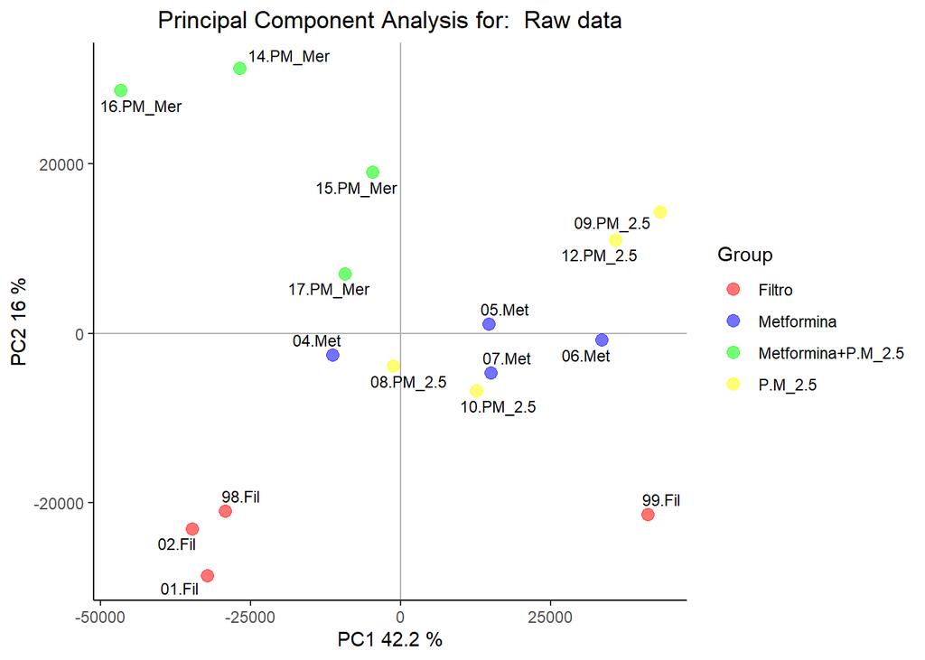

```r
plotPCA3(exprs(rawData), labels = myTargets$ShortName, factor = myTargets$grupos,
    title = "Raw data", scale = FALSE, size = 3, colores = c("red", "blue", "green",
        "yellow"))
```

Visualización de los dos primeros componentes principales para datos brutos

Tenga en cuenta que hemos definido en la función algunos parámetros para facilitar la visualización.

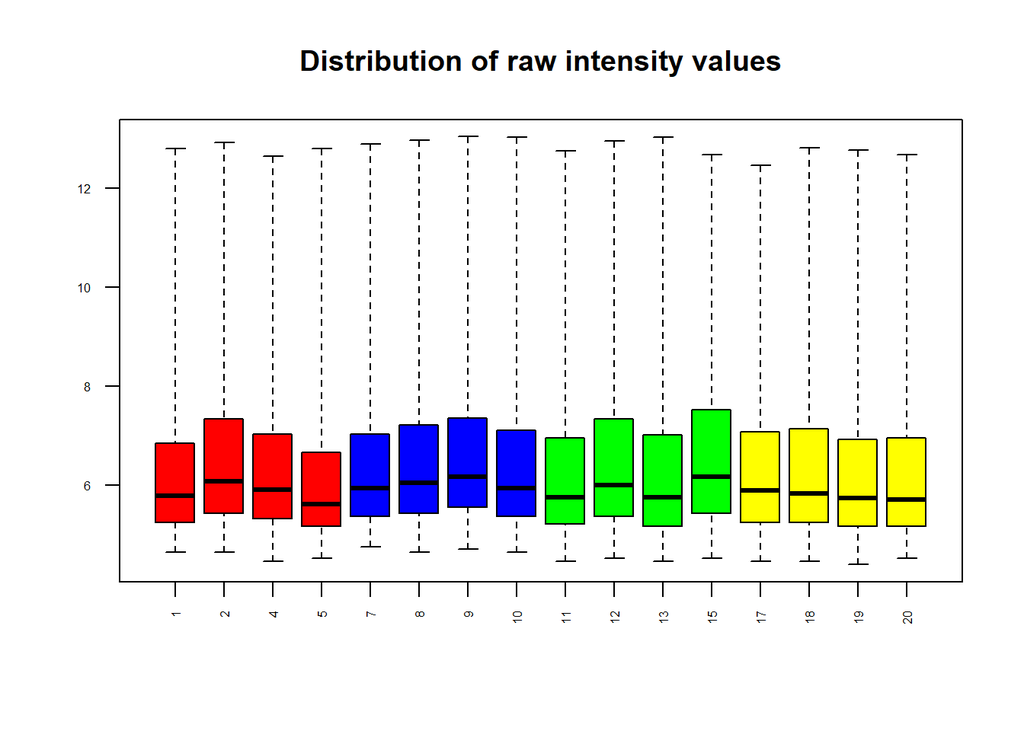

```r
boxplot(rawData, cex.axis = 0.5, las = 2, which = "all", col = c(rep("red", 4), rep("blue",
    4), rep("green", 4), rep("yellow", 4)), main = "Distribution of raw intensity values")
```

Diagrama de caja para intensidades de matrices (datos sin procesar)

Se observa una ligera variación de intensidad entre los arreglos, pero esto es lo esperado para los datos brutos.

# 6 Normalización de datos

Antes de comenzar con el análisis de expresión diferencial, es necesario hacer los arreglos comparables entre ellos y tratar de reducir, y si es posible eliminar, toda la variabilidad en las muestras no por razones biológicas El proceso de normalización intenta asegurar que las diferencias de intensidad presente en la matriz, refleja la expresión diferencial de los genes, en lugar de sesgos artificiales debidos a problemas técnicos. El proceso de normalización consta de tres pasos discretos: corrección de fondo, normalización y resumen. El método más utilizado para la normalización de matrices es el análisis robusto de múltiples chips Irizarry et al. ( 2003 ) :

```r
eset_rma <- rma(rawData)
```

```
Background correcting
Normalizing
Calculating Expression
```

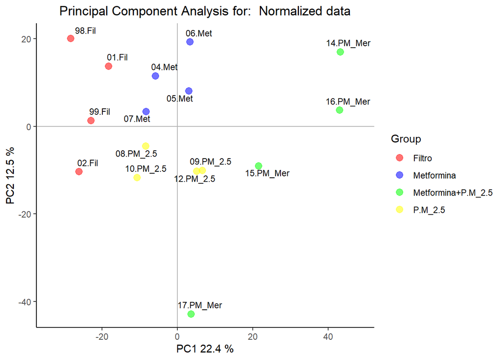

```r
plotPCA3(exprs(eset_rma), labels = myTargets$ShortName, factor = myTargets$grupos,
    title = "Normalized data", scale = FALSE, size = 3, colores = c("red", "blue",
        "green", "yellow"))
```

Visualización de los dos primeros componentes principales para datos normalizados

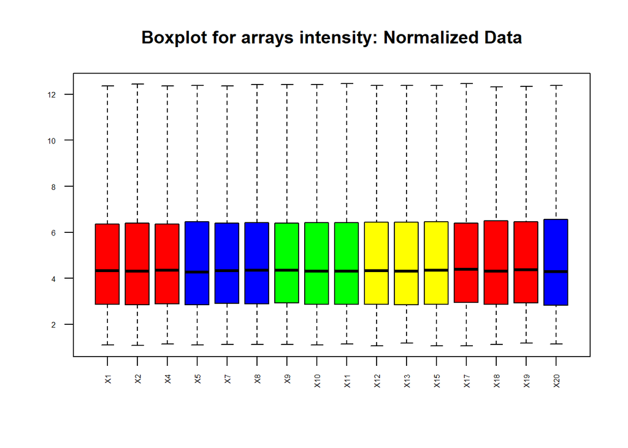

```r
boxplot(eset_rma, cex.axis = 0.5, las = 2, which = "all", col = c(rep("red", 3),
    rep("blue", 3), rep("green", 3), rep("yellow", 3)), main = "Boxplot for arrays intensity: Normalized Data")
```

Distribución de intensidades para datos normalizados.

# 7 Detección de lotes

Los resultados de los microarrays de expresión génica pueden verse afectados por diferencias minúsculas en cualquier número de variables no biológicas, como reactivos de diferentes lotes, diferentes técnicos y el problema más habitual, la fecha de procesamiento diferente de las muestras del mismo experimento. El error acumulativo introducido por estas variaciones experimentales dependientes del tiempo y el lugar se denomina “efectos de lote”. Se han desarrollado diferentes enfoques para identificar y eliminar los efectos por lotes de los datos de microarrays, como el análisis de variables sustitutas, el análisis de componentes de variación principal y de combate (PVCA).

Aquí usaremos el último, Análisis del componente de la variación principal, que estima la fuente y la proporción de la variación en dos pasos, el análisis del componente principal y el análisis del componente de la varianza. Todas las muestras se procesaron el mismo día (esto se puede ver usando la función get.celfile.dates()del paquete affyio), por lo que no es necesario considerar un factor de lote típico, como la “Fecha de procesamiento” .

```r
# load the library
library(pvca)
pData(eset_rma) <- myTargets
# select the threshold
pct_threshold <- 0.6
# select the factors to analyze
batch.factors <- c("grupos", "Colors")
# run the analysis
pvcaObj <- pvcaBatchAssess(eset_rma, batch.factors, pct_threshold)
```

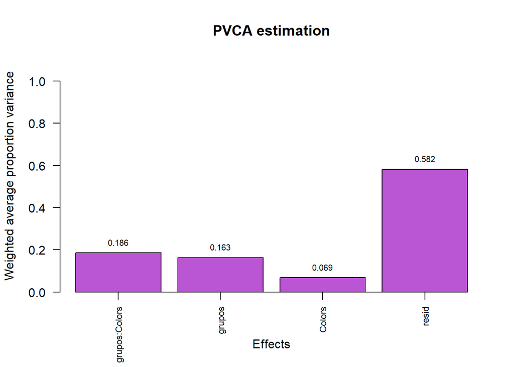

```r
# plot the results
bp <- barplot(pvcaObj$dat, xlab = "Effects", ylab = "Weighted average proportion variance",
    ylim = c(0, 1.1), col = c("mediumorchid"), las = 2, main = "PVCA estimation")
axis(1, at = bp, labels = pvcaObj$label, cex.axis = 0.75, las = 2)
values = pvcaObj$dat
new_values = round(values, 3)
text(bp, pvcaObj$dat, labels = new_values, pos = 3, cex = 0.7)
```

# 8 Detección de la mayoría de genes variables

La selección de genes expresados diferencialmente se ve afectada por el número de genes en los que la producimos. Cuanto mayor sea el número, mayor será el ajuste necesario de los p-valores (como se verá a continuación), lo que nos llevará a acabar perdiendo más genes.

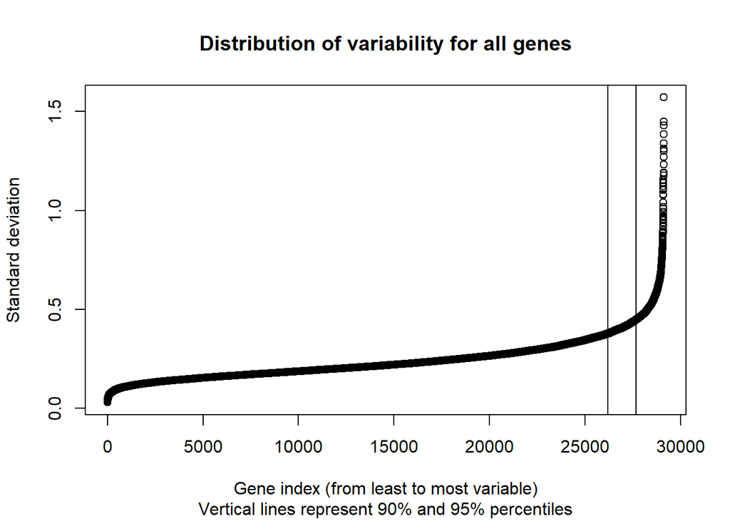

```r
sds <- apply(exprs(eset_rma), 1, sd)
sdsO <- sort(sds)
plot(1:length(sdsO), sdsO, main = "Distribution of variability for all genes", sub = "Vertical lines represent 90% and 95% percentiles",
    xlab = "Gene index (from least to most variable)", ylab = "Standard deviation")
abline(v = length(sds) * c(0.9, 0.95))
```

alores de desviaciones estándar en todas las muestras para todos los genes ordenados de menor a mayor

# 9 Filtrado de genes menos variables

Filtrar aquellos genes cuya variabilidad puede atribuirse a una variación aleatoria, es decir, los genes que, razonablemente, no se espera que se expresen diferencialmente, ha demostrado ser útil para reducir el número de pruebas a realizar con el correspondiente aumento de potencia Hackstadt y Hess ( 2009 ) .

La función nsFilterdel paquete bioconductor genefilterse puede utilizar para eliminar genes en función de un umbral de variabilidad. Si se dispone de un paquete de anotaciones, que asocia identificadores de conjuntos de sondas e identificadores de genes de diferentes bases de datos, también se puede utilizar para eliminar conjuntos de sondas que no tengan un identificador de genes asociado.

```r
# BiocManager :: install ('mogene21sttranscriptcluster.db')
library(org.Mm.eg.db)
library(AnnotationDbi)
library(genefilter)
library(mogene21sttranscriptcluster.db)
```

```r
library(genefilter)
library(clariomsmousetranscriptcluster.db)
annotation(eset_rma) <- "clariomsmousetranscriptcluster.db"
filtered <- nsFilter(eset_rma, require.entrez = TRUE, remove.dupEntrez = TRUE, var.filter = TRUE,
    var.func = IQR, var.cutoff = 0.75, filterByQuantile = TRUE, feature.exclude = "^AFFX")
```

La función nsFilterdevuelve los valores filtrados y un informe de los resultados del filtrado.

```r
print(filtered$filter.log)
```

```
$numDupsRemoved
[1] 140

$numLowVar
[1] 15058

$numRemoved.ENTREZID
[1] 8911
```

```r
eset_filtered <- filtered$eset
```

Los datos filtrados normalizados son el punto de partida para análisis adicionales, pero es posible que queramos volver a ellos, por ejemplo, para revisar valores específicos de expresión génica. Es habitual guardar los objetos binarios, pero también escribir valores de expresión en archivos de texto o Excel. Escribir en Excel desde R no es una tarea trivial -por extraño que parezca- porque los diferentes paquetes funcionan de manera diferente según el sistema operativo, por lo que se omite del código.

```r
write.csv(exprs(eset_rma), file = "./result/normalized.Data.csv")
write.csv(exprs(eset_filtered), file = "./result//normalized.Filtered.Data.csv")
save(eset_rma, eset_filtered, file = "./result/normalized.Data.Rda")
```

Definición de la configuración experimental: la matriz de diseño

La selección de genes expresados diferencialmente consiste básicamente en realizar algún tipo de prueba, generalmente genéticamente, para comparar la expresión génica entre grupos. Esto se puede hacer usando muchos enfoques diferentes (ver Chrominski y Tkacz ( 2015 ) ). Existe un acuerdo general de que el uso de pruebas estadísticas estándar, como las pruebas t, no es apropiado. Jeanmougin et al. ( 2010 ) y que mejores opciones son métodos que realizan algún tipo de reducción de varianza Allison et al. ( 2006 ) . Técnicas desarrolladas específicamente para microarrays como SAM Tusher, Tibshirani y Chu ( 2001 ) o modelos lineales para microarrays Smyth (2004 ) han demostrado producir resultados mucho mejores Chrominski y Tkacz ( 2015 ) .

En este protocolo, el método de modelos lineales para microarrays, implementado en el paquete limma Smyth ( 2005 ), se utiliza para seleccionar genes expresados diferencialmente.

El primer paso para el análisis basado en modelos lineales es crear la matriz de diseño . Básicamente es una tabla que describe la asignación de cada muestra a un grupo o condición experimental. Tiene tantas filas como muestras y tantas columnas como grupos (si solo se considera un factor). Cada fila contiene un uno en la columna del grupo al que pertenece la muestra y un cero en las demás.

```r
if (!exists("eset_filtered")) load(file = "/normalized.Data.Rda")
```

```r
library(limma)
designMat <- model.matrix(~0 + grupos, pData(eset_filtered))
colnames(designMat) <- c("Filtro", "Metformina", "PM_2.5", "Metformina_PM_2.5")
print(designMat)
```

```
   Filtro Metformina PM_2.5 Metformina_PM_2.5
1       1          0      0                 0
2       1          0      0                 0
4       1          0      0                 0
5       1          0      0                 0
7       0          1      0                 0
8       0          1      0                 0
9       0          1      0                 0
10      0          1      0                 0
11      0          0      0                 1
12      0          0      0                 1
13      0          0      0                 1
15      0          0      0                 1
17      0          0      1                 0
18      0          0      1                 0
19      0          0      1                 0
20      0          0      1                 0
attr(,"assign")
[1] 1 1 1 1
attr(,"contrasts")
attr(,"contrasts")$grupos
[1] "contr.treatment"
```

# 10 Definición de comparaciones con la matriz de contrastes

```r
# Definición de la matriz de contraste
library(limma)
cont.matrix <- makeContrasts(FiltrovsMetformina = Filtro - Metformina, FiltrovsMetformina_PM_2.5 = Filtro -
    Metformina_PM_2.5, MetforminavsMetformina_PM_2.5 = Metformina - Metformina_PM_2.5,
    levels = designMat)
print(cont.matrix)
```

```
                   Contrasts
Levels              FiltrovsMetformina FiltrovsMetformina_PM_2.5
  Filtro                             1                         1
  Metformina                        -1                         0
  PM_2.5                             0                         0
  Metformina_PM_2.5                  0                        -1
                   Contrasts
Levels              MetforminavsMetformina_PM_2.5
  Filtro                                        0
  Metformina                                    1
  PM_2.5                                        0
  Metformina_PM_2.5                            -1
```

# 11 Estimación del modelo y selección de genes

Una vez definida la matriz de diseño y los contrastes, podemos proceder a estimar el modelo, estimar los contrastes y realizar las pruebas de significancia que conducirán a la decisión, para cada gen y cada comparación, si se pueden considerar expresados diferencialmente.

El método implementado en el limmapaquete extiende el análisis tradicional usando modelos empíricos de Bayes para combinar una estimación de variabilidad basada en la matriz completa con estimaciones individuales basadas en cada valor individual proporcionando estimaciones de error mejoradas Smyth ( 2004 ) .

El análisis proporciona las estadísticas de prueba habituales, como valores de p ajustados o moderados por t de cambio de pliegues que se utilizan para ordenar los genes de más, a menos que se expresen de forma diferencial.

Para controlar el porcentaje de falsos positivos que pueden resultar de un elevado número de contrastes realizados simultáneamente se ajustan los valores p para que tengamos control sobre la tasa de falsos positivos utilizando el método de Benjamini y Hochberg Benjamini y Hochberg ( 1995 ) .

Toda la información relevante para una mayor exploración de los resultados se almacena en un objeto R de clase MArrayLMdefinido en el limmapaquete. Aquí se nombra como fit.main.

```r
# --------------------------------------------- Estimación del modelo y
# selección de genes ---------------------------------------------

library(limma)
fit <- lmFit(eset_filtered, designMat)
fit.main <- contrasts.fit(fit, cont.matrix)
fit.main <- eBayes(fit.main)
class(fit.main)
```

```
[1] "MArrayLM"
attr(,"package")
[1] "limma"
```

```r
# --------------------------------------------- Listas de genes
# diferencialmente expresados ---------------------------------------------

topTab_FiltrovsMetformina <- topTable(fit.main, number = nrow(fit.main), coef = "FiltrovsMetformina",
    adjust = "fdr")
head(topTab_FiltrovsMetformina)
```

```
                     logFC  AveExpr        t      P.Value    adj.P.Val        B
TC1500000782.mm.2 2.956274 4.668720 9.235905 1.127057e-08 5.657826e-05 9.789943
TC1100003775.mm.2 1.988072 9.837696 8.294143 6.374125e-08 1.467697e-04 8.249479
TC0500002731.mm.2 1.216264 6.064329 8.127136 8.771099e-08 1.467697e-04 7.962124
TC0900001253.mm.2 1.894707 4.297988 7.519236 2.892543e-07 3.630141e-04 6.879278
TC1100004233.mm.2 2.058695 9.339307 7.179914 5.753357e-07 4.911780e-04 6.249565
TC1100003409.mm.2 1.368449 8.755905 7.170069 5.870653e-07 4.911780e-04 6.231025
```

```r
topTab_FiltrovsMetformina_PM_2.5 <- topTable(fit.main, number = nrow(fit.main), coef = "FiltrovsMetformina_PM_2.5",
    adjust = "fdr")
head(topTab_FiltrovsMetformina_PM_2.5)
```

```
                      logFC  AveExpr         t      P.Value    adj.P.Val
TC0500002731.mm.2  1.344404 6.064329  8.983379 1.773875e-08 7.902341e-05
TC0700001723.mm.2  1.368218 7.714326  8.670158 3.148343e-08 7.902341e-05
TC0900000205.mm.2  1.695202 8.421954  7.566773 2.630146e-07 4.401112e-04
TC1200000839.mm.2 -1.387156 5.530653 -7.288466 4.609468e-07 5.366105e-04
TC0900001253.mm.2  1.818274 4.297988  7.215906 5.344726e-07 5.366105e-04
TC1500000782.mm.2  2.098017 4.668720  6.554566 2.127453e-06 1.779969e-03
                         B
TC0500002731.mm.2 9.306086
TC0700001723.mm.2 8.804971
TC0900000205.mm.2 6.917957
TC1200000839.mm.2 6.411486
TC0900001253.mm.2 6.277412
TC1500000782.mm.2 5.017202
```

```r
topTab_MetforminavsMetformina_PM_2.5 <- topTable(fit.main, number = nrow(fit.main),
    coef = "MetforminavsMetformina_PM_2.5", adjust = "fdr")
head(topTab_MetforminavsMetformina_PM_2.5)
```

```
                       logFC  AveExpr         t      P.Value    adj.P.Val
TC0700001660.mm.2 -1.6198752 6.931768 -8.506973 4.266281e-08 0.0002141673
TC1200001549.mm.2 -0.9440427 5.666546 -7.474462 3.164465e-07 0.0007942807
TC1000000843.mm.2 -1.2597052 7.095210 -6.105434 5.616379e-06 0.0049543089
TC0600001810.mm.2 -1.7170252 7.222567 -6.091912 5.785222e-06 0.0049543089
TC0700001723.mm.2  0.9451140 7.714326  5.989019 7.253097e-06 0.0049543089
TC1500001954.mm.2  0.9887805 7.923248  5.953630 7.842036e-06 0.0049543089
                         B
TC0700001660.mm.2 8.380525
TC1200001549.mm.2 6.645073
TC1000000843.mm.2 4.078479
TC0600001810.mm.2 4.051676
TC0700001723.mm.2 3.846846
TC1500001954.mm.2 3.776043
```

```r
# --------------------- Anotación de genes ---------------------

annotatedTopTable <- function(topTab, anotPackage) {
    topTab <- cbind(PROBEID = rownames(topTab), topTab)
    myProbes <- rownames(topTab)
    thePackage <- eval(parse(text = anotPackage))
    geneAnots <- select(thePackage, myProbes, c("SYMBOL", "ENTREZID", "GENENAME"))
    annotatedTopTab <- merge(x = geneAnots, y = topTab, by.x = "PROBEID", by.y = "PROBEID")
    return(annotatedTopTab)
}

topAnnotated_FiltrovsMetformina <- annotatedTopTable(topTab_FiltrovsMetformina, anotPackage = "clariomsmousetranscriptcluster.db")
topAnnotated_FiltrovsMetformina_PM_2.5 <- annotatedTopTable(topTab_FiltrovsMetformina_PM_2.5,
    anotPackage = "clariomsmousetranscriptcluster.db")
topAnnotated_MetforminavsMetformina_PM_2.5 <- annotatedTopTable(topTab_MetforminavsMetformina_PM_2.5,
    anotPackage = "clariomsmousetranscriptcluster.db")
write.csv(topAnnotated_FiltrovsMetformina, file = "./result/topAnnotated_FiltrovsMetformina.csv")
write.csv(topAnnotated_FiltrovsMetformina_PM_2.5, file = "./result/topAnnotated_FiltrovsMetformina_PM_2.5.csv")
write.csv(topAnnotated_MetforminavsMetformina_PM_2.5, file = "./result/topAnnotated_MetforminavsMetformina_PM_2.5.csv")
```

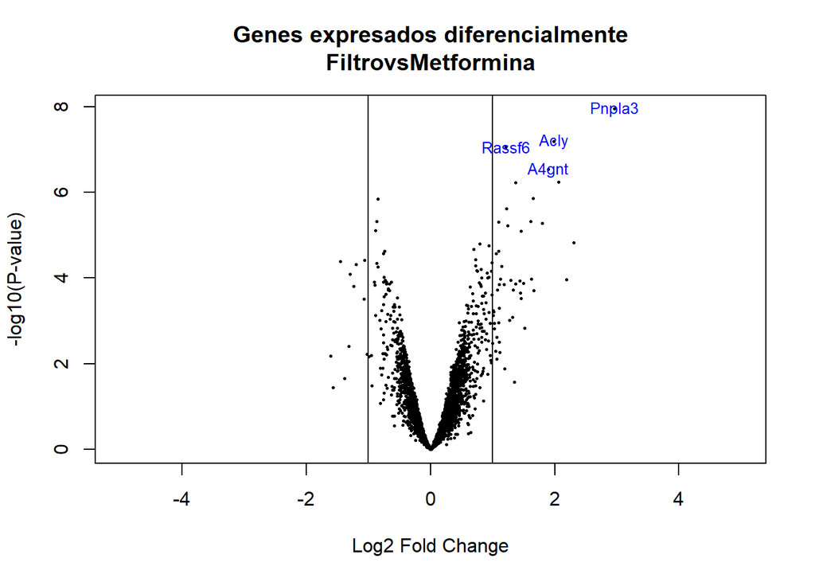

```r
# ------------------------------------ Gráficos de volcán (VOLCANO-PLOTS)
# ------------------------------------

library(clariomsmousetranscriptcluster.db)
geneSymbols <- select(clariomsmousetranscriptcluster.db, rownames(fit.main), c("SYMBOL"))
SYMBOLS <- geneSymbols$SYMBOL
volcanoplot(fit.main, coef = 1, highlight = 4, names = SYMBOLS, main = paste("Genes expresados diferencialmente",
    colnames(cont.matrix)[1], sep = "\n"), xlim = c(-5, 5))
abline(v = c(-1, 1))
```

```r
# ------------------------------------------- Comparación entre distintas
# comparaciones -------------------------------------------

library(limma)
res <- decideTests(fit.main, method = "separate", adjust.method = "fdr", p.value = 0.1,
    lfc = 1)

sum.res.rows <- apply(abs(res), 1, sum)
res.selected <- res[sum.res.rows != 0, ]
print(summary(res))
```

```
       FiltrovsMetformina FiltrovsMetformina_PM_2.5
Down                    7                        16
NotSig               4970                      4985
Up                     43                        19
       MetforminavsMetformina_PM_2.5
Down                               9
NotSig                          5008
Up                                 3
```

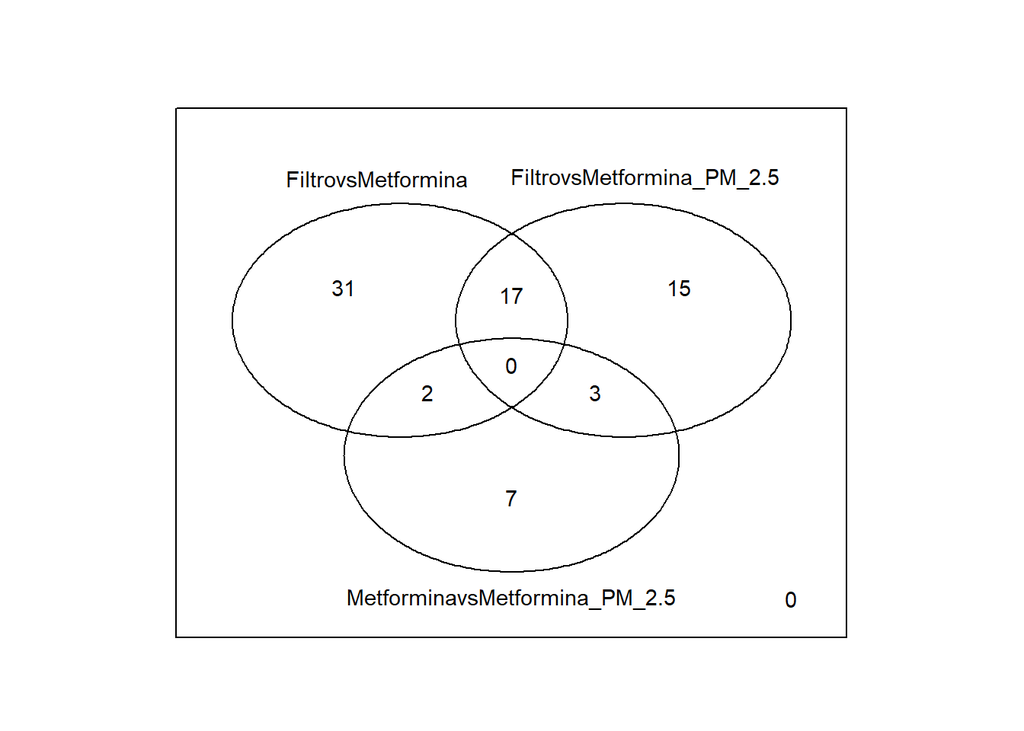

```r
# ------------------------------------------- Anotación de resultados -
# Diagrama de Venn -------------------------------------------

vennDiagram(res.selected[, 1:3], cex = 0.9)
```

```r
NA
```

```
[1] NA
```

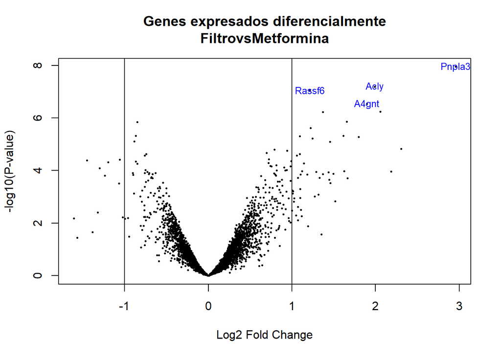

```r
geneSymbols <- select(clariomsmousetranscriptcluster.db, rownames(fit.main), c("SYMBOL"))
SYMBOLS <- geneSymbols$SYMBOL
volcanoplot(fit.main, coef = 1, highlight = 4, names = SYMBOLS, main = paste("Genes expresados diferencialmente",
    colnames(cont.matrix)[1], sep = "\n"))
abline(v = c(-1, 1))
```

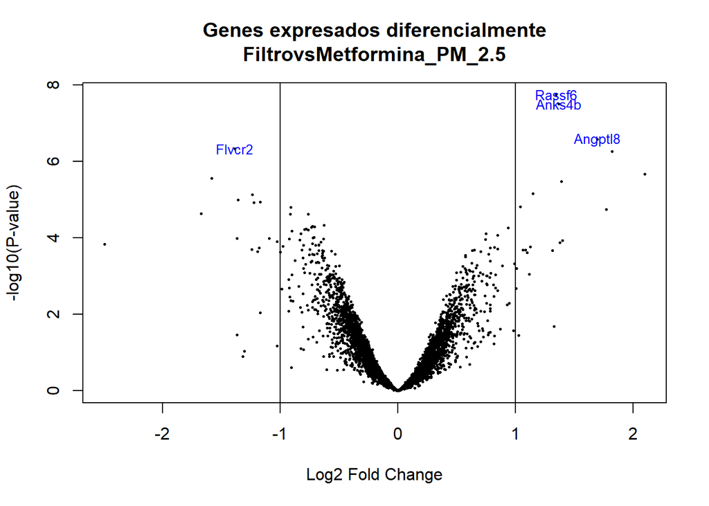

```r
geneSymbols <- select(clariomsmousetranscriptcluster.db, rownames(fit.main), c("SYMBOL"))
SYMBOLS <- geneSymbols$SYMBOL
volcanoplot(fit.main, coef = 2, highlight = 4, names = SYMBOLS, main = paste("Genes expresados diferencialmente",
    colnames(cont.matrix)[2], sep = "\n"))
abline(v = c(-1, 1))
```

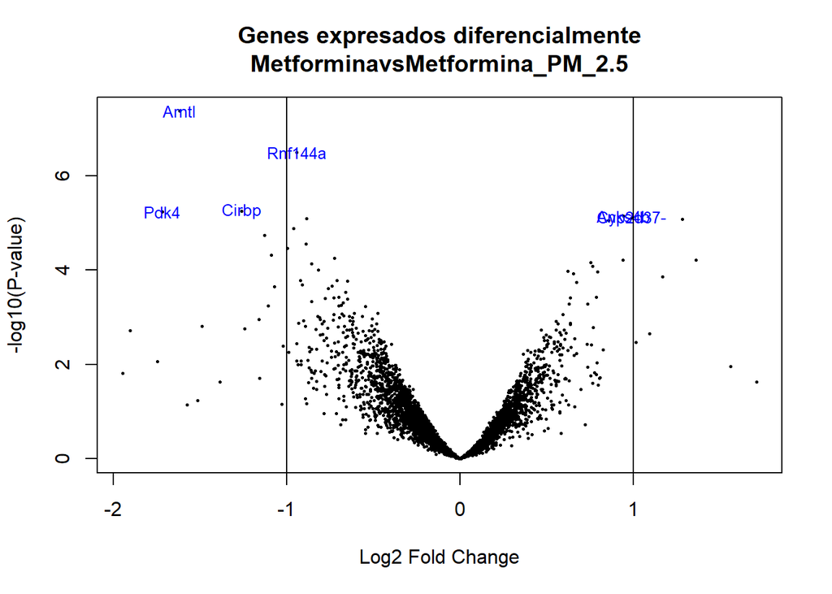

```r
# ============================================ Volcano plot
# ============================================

geneSymbols <- select(clariomsmousetranscriptcluster.db, rownames(fit.main), c("SYMBOL"))
SYMBOLS <- geneSymbols$SYMBOL
volcanoplot(fit.main, coef = 3, highlight = 6, names = SYMBOLS, main = paste("Genes expresados diferencialmente",
    colnames(cont.matrix)[3], sep = "\n"))
abline(v = c(-1, 1))
```

```r
# ============================================ Contar cuantos genes se han
# diferenciado: negativa y positivamente
# ============================================

res <- decideTests(fit.main, method = "separate", adjust.method = "fdr", p.value = 0.1,
    lfc = 1)

sum.res.rows <- apply(abs(res), 1, sum)
res.selected <- res[sum.res.rows != 0, ]
```

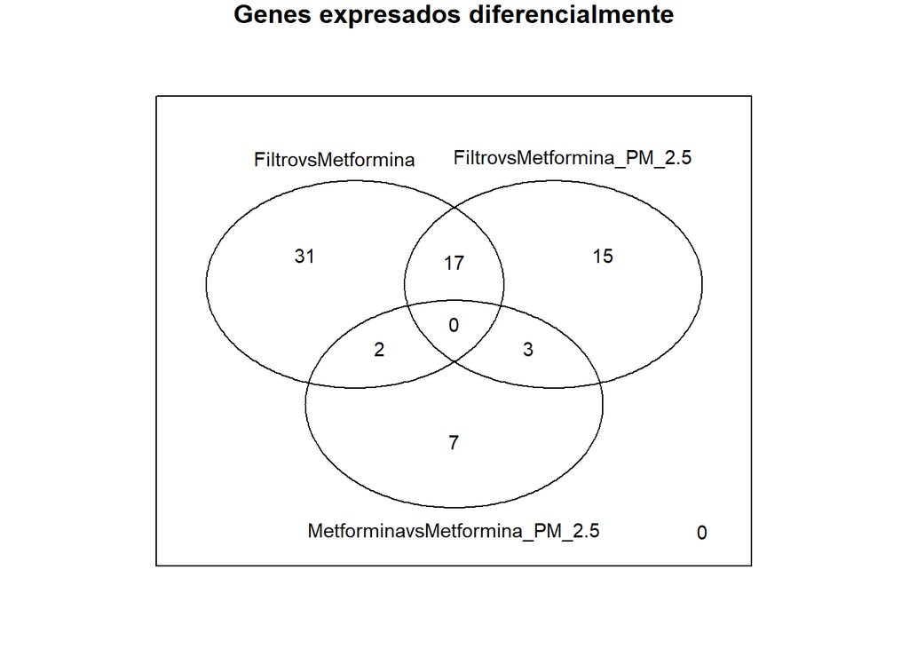

```r
# ============================================ Diagrama de Venn para visualizar
# los genes diferenciados ============================================

vennDiagram(res.selected[, 1:3], cex = 0.9, main = paste("Genes expresados diferencialmente"))
```

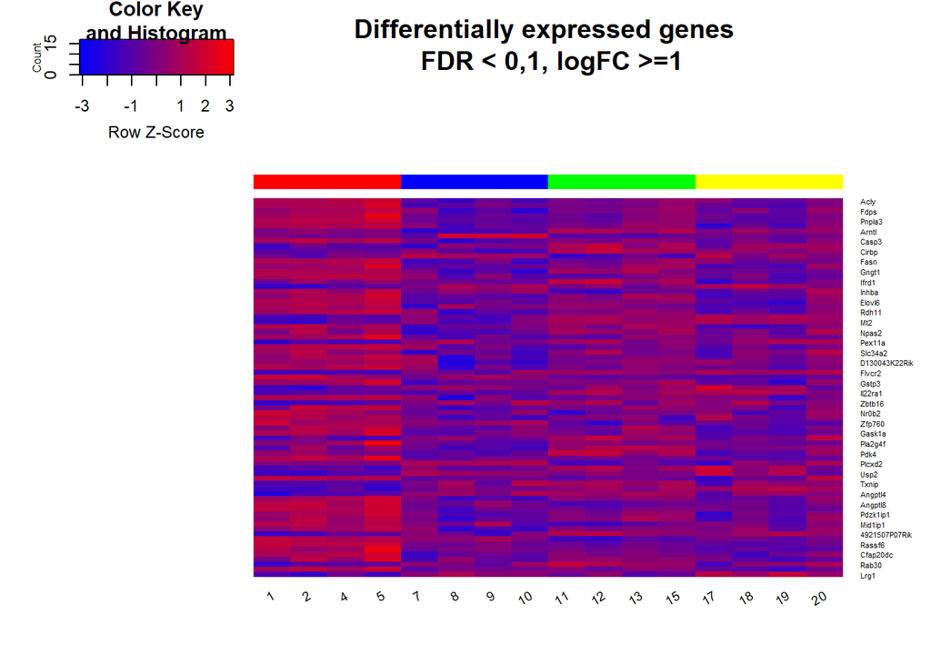

```r
# ============================================ Clustered heatmap
# ============================================

probesInHeatmap <- rownames(res.selected)
HMdata <- exprs(eset_filtered)[rownames(exprs(eset_filtered)) %in% probesInHeatmap,
    ]
geneSymbols <- select(clariomsmousetranscriptcluster.db, rownames(HMdata), c("SYMBOL"))
SYMBOLS <- geneSymbols$SYMBOL
rownames(HMdata) <- SYMBOLS
write.csv(HMdata, file = file.path("./result/data4Heatmap.csv"))
my_palette <- colorRampPalette(c("blue", "red"))(n = 299)
library(gplots)
heatmap.2(HMdata, Rowv = FALSE, Colv = FALSE, main = "Differentially expressed genes \n FDR < 0,1, logFC >=1",
    scale = "row", col = my_palette, sepcolor = "white", sepwidth = c(0.05, 0.05),
    cexRow = 0.5, cexCol = 0.9, key = TRUE, keysize = 1.5, density.info = "histogram",
    ColSideColors = c(rep("red", 4), rep("blue", 4), rep("green", 4), rep("yellow",
        4)), tracecol = NULL, dendrogram = "none", srtCol = 30)
```

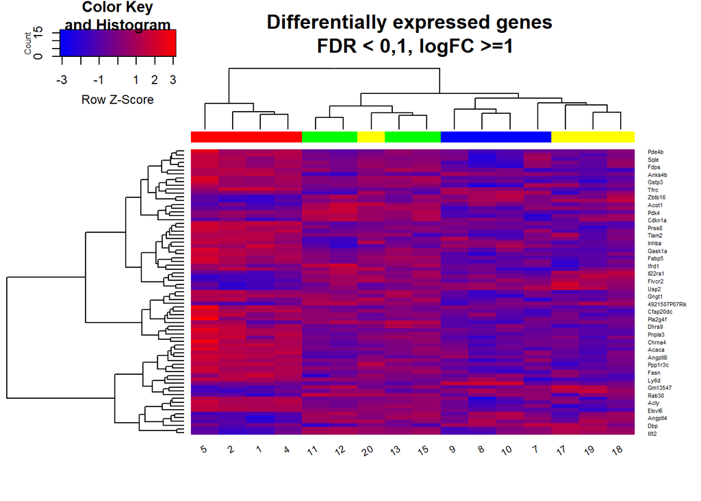

```r
heatmap.2(HMdata, Rowv = TRUE, Colv = TRUE, dendrogram = "both", main = "Differentially expressed genes \n FDR < 0,1, logFC >=1",
    scale = "row", col = my_palette, sepcolor = "white", sepwidth = c(0.05, 0.05),
    cexRow = 0.5, cexCol = 0.9, key = TRUE, keysize = 1.5, density.info = "histogram",
    ColSideColors = c(rep("red", 4), rep("blue", 4), rep("green", 4), rep("yellow",
        4)), tracecol = NULL, srtCol = 30)
```

# Importancia biológica de los resultados

Una vez que se ha obtenido una lista de genes que caracterizan la diferencia entre dos condiciones, hay que interpretarla. Aunque esto requiere, por supuesto, una buena comprensión del problema biológico subyacente, un enfoque estadístico conocido como “análisis de conjuntos de genes” puede ser útil para sugerir ideas para la interpretación.